# Juvenile snowshoe hares: exploratory report

By: Allison Gracer

11/3/2021

## 1. Overview

This report provides an exploratory overview of differences in juvenile Snowshoe hare weights observed across three study sites(Bonanza Black Spruce, Bonanza Mature, and Bananza Riparian) in the Bonanza Creek Experimental Forest, located in the Tanana Valley in Alaska from 1999-2012 (Kielland et al. 2017). Specifically, hare weights are compared across three study sites, broken out by sex to account for sexual dimorphism within a species. Additionally, the relationship(s) between hind foot length and body mass are explored.

## 2. Data and methods

Snowshoe structural size measurement data were collected in a capture re-capture study and made available by Knut Kielland and colleagues at the Bonanza Creek Experimental Forest, part of the Bonanza Creek Long Term Ecological Research (LTER) network site located near Fairbanks, Alaska. The data contain 378 observations for juvenile Snowshoe hares collected from 1999-2012. Following exploratory data visualization, body weight between male and female hares are compared by unpaired two-sample t-tests using a significance level ($\alpha$) of 0.05 throughout. Difference between groups are described by Cohen’s *d* effect size. The relationship between hind foot length and body weight is explored by simple linear regression. All analyses are in R version 4.0.2 using RStudio version 1.4.1717.

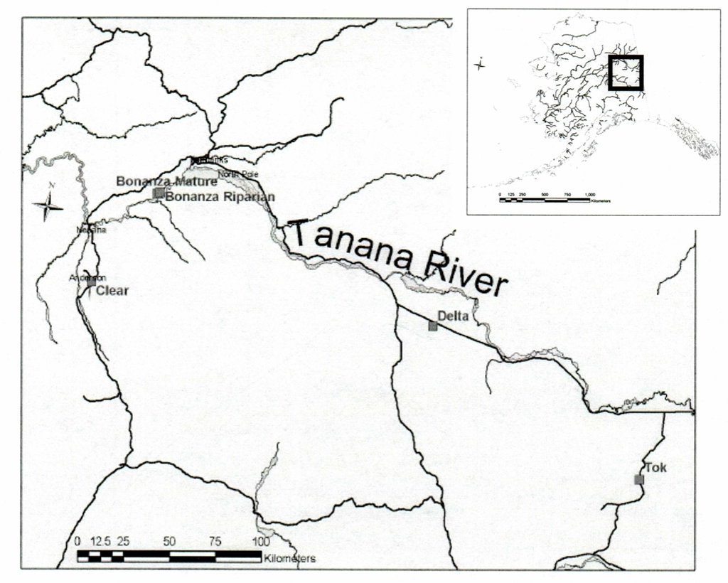

**Figure 1.** Map of snowshoe hare observations in the Bonanza LTER network site from Bjorn Flora (2002).

## 3. Preliminary results

### A. Annual juvenile hare trap counts

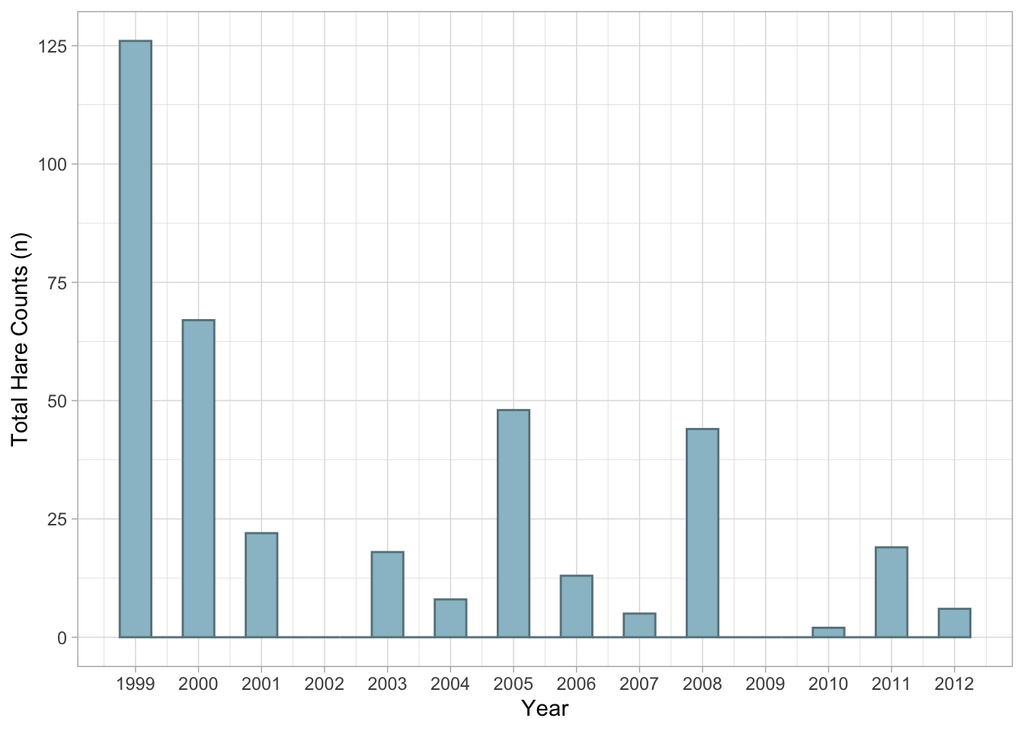

**Figure 2.** This graph shows the total counts of Bonanza LTER juvenile snowshoe hare trappings across all three study sites between 1999 and 2012.

The minimum count of juvenile hare trappings is 2 and the maximum count is 126. A notable trend these values indicate is a decline in juvenile snowshoe traps over time. The mean count of juvenile hare trappings is 31.5 and the median is 18.5. The data used in this report are absolute counts, but does not take into consideration the impact of effort, or number of days and number of traps used in the study each year. These factors would need to be taken into consideration for future analyses to standardize the juvenile hare population.

### B. Visualize juvenile hare weights

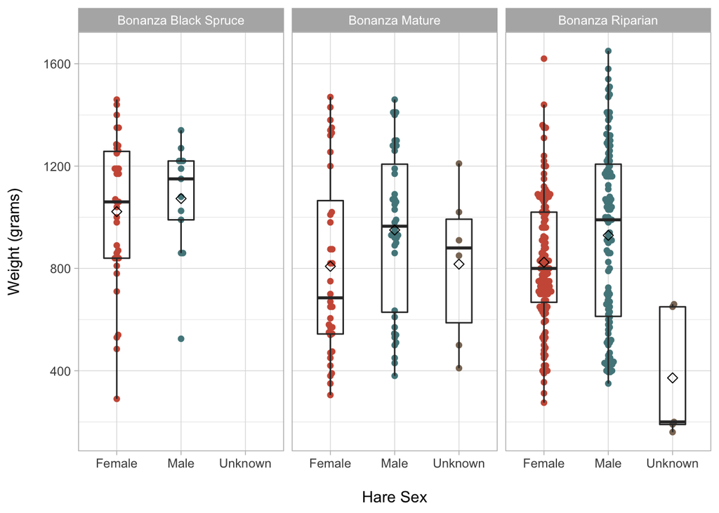

**Figure 3.** This graph shows the distribution of juvenile snowshoe hare weights by sex across three study sites. Coral (female), blue (male), and gray (Unknown) points indicate individual observations for hare weight of a juvenile snowshoe hare. Unknown observations are included, and are observations where the weights were recorded but sex was not. Box endpoints indicate the 25<sup>th</sup> and 75<sup>th</sup> percentile values; the black line and black point within the box indicate the median and mean value for each species, respectively. Data: Kielland et al. (2017).

This visualization shows that both male and female juvenile snowshoe hare weights appear to be normally distributed across all three sites. This appears to be the case even though the Bonanza Riparian site has far more observations than the other two sites. The number of observations could be attributed to actual population size at each site or due to the effort in collecting data at each site, which should be considered for future analyses.

### C. Juvenile weight comparison (male & female snowshoe hares)

Table 1: Descriptive statistics (mean, standard deviation, and sample size) for male and female juvenile snowshoe hares. Data: Keilland et al. 2017

| Sex | Mean Weight (g) | Standard Deviation (g) | Sample Size (n) |
| --- | --- | --- | --- |
| Female | 855.39 | 292.25 | 200 |
| Male | 945.86 | 333.22 | 163 |
| Unknown | 614.55 | 357.59 | 15 |

On average, juvenile male snowshoe hares have larger body weights than juvenile female snowshoe hares (945.86 $\pm$ 333.22 and 855.39 $\pm$ 292.25 grams, respectively; mean $\pm$ 1 standard deviation). While the absolute difference in means is 90.47 grams (a 10.05 % difference), the difference in means is statistically significant (Welch’s two-sample t-test: t(325.02) = 2.71, p = 0.007), and the effect size is small (Cohen’s *d* = 0.29).

### D. Relationship between juvenile weight & hind foot length

As a starting point, the relationship between hind foot length and body weight was explored for all juvenile snowshoe hares (i.e. ignoring sex); further analysis is needed to compare the relationship between hind foot length and body weight.

The relationship between hind foot length(mm) and body weight (g) does not appear to be completely linear (Figure 4). Simple linear regression revealed that hind foot length significantly predicts body weight (p < 0.001, R<sup>2</sup> = 0.3) with an average slope of $\beta$ = 9.52 g mm<sup>-1</sup> (i.e., for each one millimeter increase in hind foot length we expect an average increase in body mass of 9.52 g). Hind foot length and body weight are moderately positively correlated (Pearson’s *r* = 0.55, p < 0.001). Diagnostic plots (not included in this report) reveal non-normal distributions and heteroscedastic residuals.

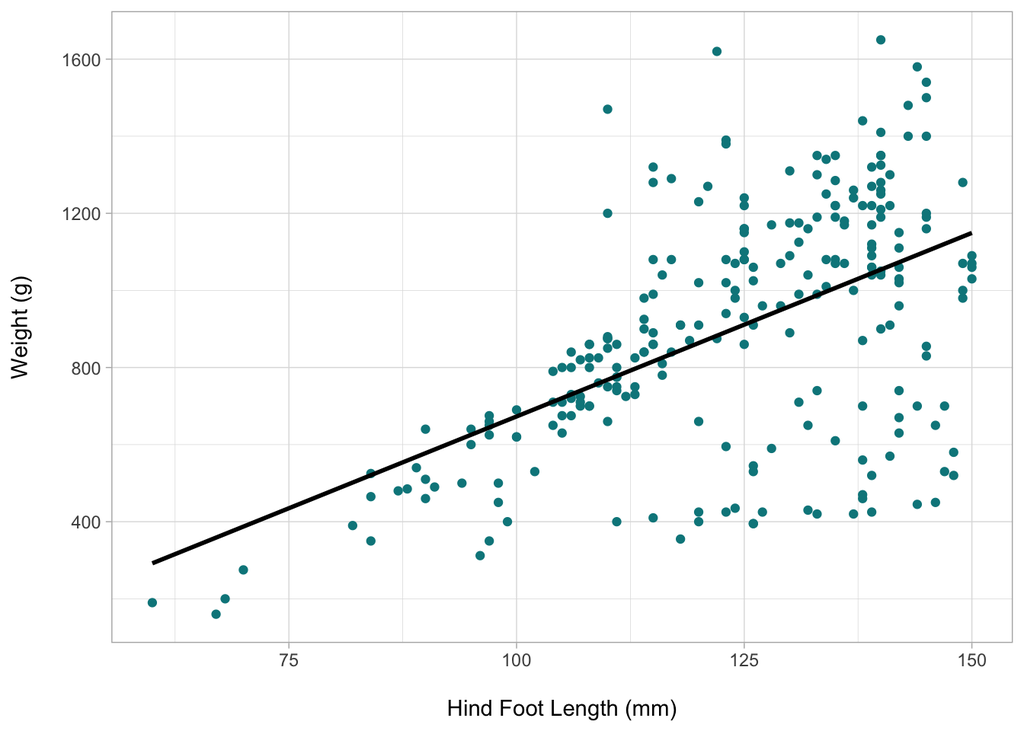

**Figure 4.** Relationship between hind foot length(mm) and body mass (g) in juvenile snowshoe hares. Points indicate individual juvenile snowshoe hare measurements. Linear model summary: $\beta$ = 9.52 g mm<sup>-1</sup>, p < 0.001, R<sup>2</sup> = 0.3, Pearson’s *r* = 0.55). Data: Kielland et al. (2017).

## Citations

Kielland, K., F.S. Chapin, R.W. Ruess, and Bonanza Creek LTER. 2017. Snowshoe hare physical data in Bonanza Creek Experimental Forest: 1999-Present ver 22. Environmental Data Initiative. https://doi.org/10.6073/pasta/03dce4856d79b91557d8e6ce2cbcdc14